# Tarea7_CCC_103531

## Spark

### **Notas aclaratorias**

Para resolver mi tarea primero intenté hacerlo con pyspark desde un *notebook* de **Jupyter** en mi **docker**, todo corrió bien y revisé que todos mis ejercicios corrieran considerando una pequeña fracción de los datos. Utilicé la siguiente referencia para configurar mi imagen y el *notebook*: https://medium.com/@suci/running-pyspark-on-jupyter-notebook-with-docker-602b18ac4494

La imagen que utilicé se puede encontrar en el siguiente enlace: https://github.com/jupyter/docker-stacks/tree/master/pyspark-notebook

Para poder correrlos con toda la base había que conectarlo a AWS (en otro caso, habría tomado demasiado tiempo) pero tuve un problema pues, al parecer, para correr un *notebook* de **Jupyter** es necesario instalar algunas detalles extra en el clúster, lo intenté varias veces pero por alguna razón no podía abrir mi ssh, muestro imagen de evidencia:

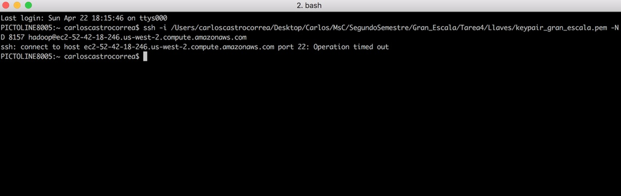

Consulté a algunos compañeros y me recomendaron utilizar Zepellin pues ya está configurado dentro de los clúster de AWS, tomé gran parte del código que había hecho en Jupuyter y pude realizar mi tarea sin problemas. **Para mayor claridad, subo mis scripts de pyspark en Jupyter y Zepellin, podrás encontrarlos en la carpeta Archivos.**

```r
#Diagrama de elementos
```

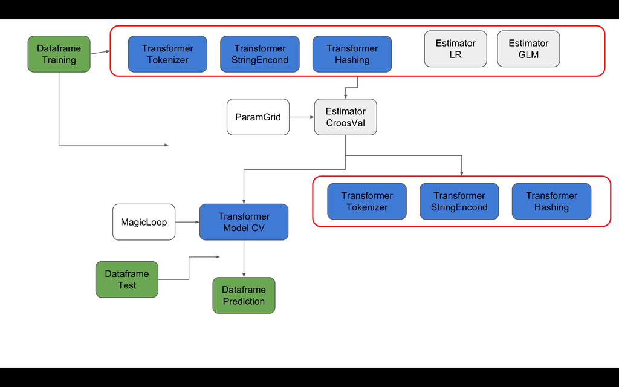

**Summary de mi clúster**

```r
#Summary de mi clúster
```

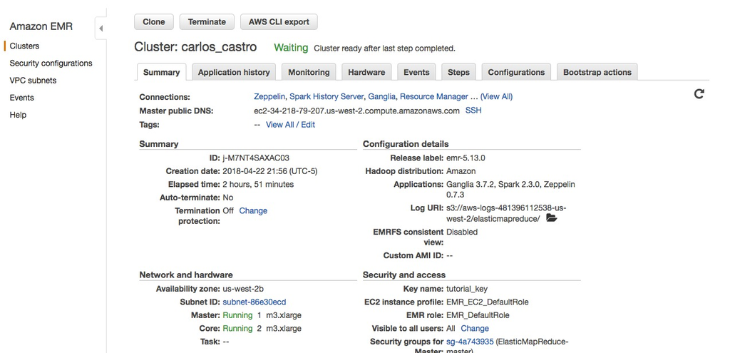

```r
#step en verde de mi script
```

En esta ocasión no utilicé la consola de AWS para agregar mis steps, abrí un *notebook* en un puerto de mi computadora y desde ahí fui corriendo mi código. Agrego una imagen del estatus *finished* de mi *notebook* así como las salidas finales de la corrida (como prueba de que terminaron mis *“steps”*):

[figure not shown]

[figure not shown]

### ¿Qué algoritmo resultó el mejor, con qué parámetros?

Para mi tarea utilicé 2 algoritmos: regresión lineal simople y modelos lineales generalizados.

Como sabemos, los MLG son una familia de distribuciones que recaen en la media mediante distintas ligas; antes de intentar la familia *Normal*, probé con las demás, por ejemplo *Gamma* y *Poisson*, sin embargo, la primea tiene un dominio positivo y la segunda es más natural para conteos, pude pensar en un reescalmiento de los datos (por ejemplo, sumarle a todos el valor absoluto del valor más chico, es decir el más negativo) pero a final de cuentas, decidí utilizar el MLG con liga *Gaussiana* optimizando parámetros distintos respecto a la regresión lineal. Para determinar el modelo ganador utilicé el **error cuadrático medio**; los resultados fueron los siguientes:

```r
#MLG - liga: Guassiana
```

**Predicciones y el error cuadrático medio correspondiente - MLG**

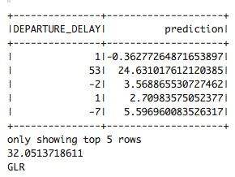

```r
#Regresión Lineal Simple
```

**Predicciones y el error cuadrático medio correspondiente - Regresión Lineal**

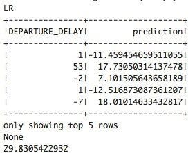

```r
#Parámetros del mejor modelo: Regresión Lineal Simple
```

**Mejor modelo**

Dado el error cuadrático medio de ambos, el mejor modelo fue la **regresión lineal simple, agrego la salida de sus parámetros**:

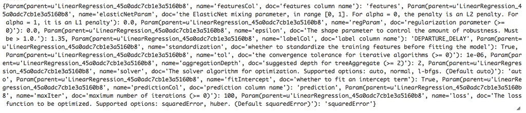

```r
#Tiempo de ejecución
```

### Indicar el tiempo de ejecución de la función de magic

**Agregando la salida directa de mi código:**

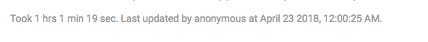